# Application of ComBat-seq on simulated dataset

Yuqing Zhang

September 14, 2018

## ComBat-seq model

We build a negative binomial GLM for adjusting for batch effect in count data. Gene-wise linear model:

$$\log(\mu_{gij}) = \alpha_g + X_j^T\beta_g + \gamma_{gi} \\
var(y_{gij}) = \mu_{gij} + \phi_{gi}\mu_{gij}^2$$

- $y_{gij}$: Counts of gene $g$ in sample $j$ from batch $i$.
- $\mu_{gij}$: Expectation of counts of gene $g$ in sample $j$ from batch $i$.
- $\alpha_g$: Background expression of gene $g$.
- $X_j^T\beta_g$: Biological condition effect of sample $j$, design matrix and corresponding coefficients.
- $\gamma_{gi}$: Mean batch parameter for batch $i$ on gene $g$.
- $\phi_{gi}$: Dispersion batch parameter for batch $i$ on gene $g$.

edgeR applies EB shrinkage on dispersion parameter $\phi_{gi}$, through weighted likelihood. But it doesn’t apply shrinkage on $\gamma_{gi}$.

## Design of the study

This example is inspired by **Figure 1** from Leek et al. 2010. We simulated a **(2000 gene $\times$ 20 sample)** count matrix from negative binomial distribution. The dataset contains **2** batches, with **10** samples in each batch, and **no biological effect**. This dataset represents a simpliest case where ComBat-seq could be useful.

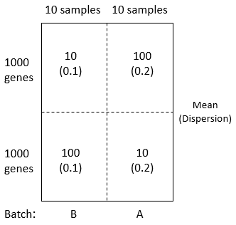

## Simulate dataset

### Distribution of counts in samples

Library sizes (average counts in each sample) are roughly similar across samples. The dispersion parameters are different in two batches (Batch B: 0.1, Batch A: 0.2).

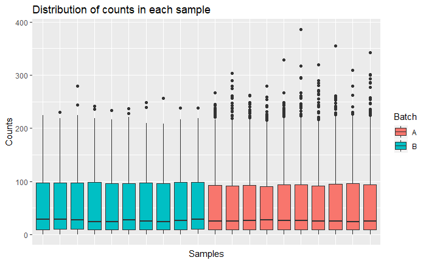

### Batch effect in the dataset

However, genes are systematically different between the two batches. The first 1000 genes are higher in Batch A, while the next 1000 genes are have larger counts in Batch B. The image in the first tab below shows 10 genes from each gene group.

In the second tab, we show hiearachical clustering of samples in the dataset based on the unadjusted counts. Samples are clearly clustered by batch.

#### Counts in genes

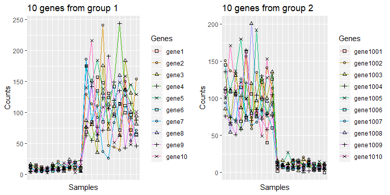

#### Clustering of samples before adjustment

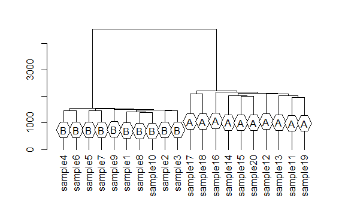

## Apply ComBat-seq

### Adjustment output

We apply ComBat-seq to the above simulated dataset. Some intermediate results of ComBat-seq are printed out to help us better understand how this function works.

```r
adj_counts <- ComBat_seq(counts=counts, batch=batch, group=group)
```

```
Found 2 batches
Using null model in ComBat-seq.
Adjusting for 0 covariate(s) or covariate level(s)

########  Design matrix  ########
Partial design matrix:
  batchA batchB
1      0      1
2      0      1
3      0      1
4      0      1
5      0      1
6      0      1


########  Dispersion  ########
Estimated common dispersion:
[1] 0.203 0.098

Average estimated gene-wise dispersion:
   batchA    batchB
0.2076074 0.1026676


########  GLM model coefs  ########
Coefficients (model 1):
         batchA    batchB
gene1 -6.973801 -9.084080
gene2 -6.932046 -9.276698
gene3 -6.986505 -9.248889
gene4 -6.850141 -9.166703
gene5 -6.675967 -9.337591
gene6 -6.921779 -9.369254
            batchA    batchB
gene1995 -9.121051 -7.174849
gene1996 -9.307461 -6.985563
gene1997 -9.598518 -6.856614
gene1998 -9.340001 -7.116388
gene1999 -8.963533 -6.883673
gene2000 -9.611298 -7.010444
```

[output cut: 34 more lines]

```

Prior average dispersion:
   batchA    batchB
0.2076074 0.1026676

Posterior average dispersion:
   batchA    batchB
0.2077033 0.1012372

Batch-free mean mu:
[1] 31.6079
[1] 31.46583

Batch-free dispersion phi:
[1] 0.1544703
```

### Visualize adjusted data

Similar as above, we visualize the adjusted counts in each sample (first tab), and in 10 genes from each gene group (second tab). Also, in the third tab, we can see that after the ComBat-seq adjustment, samples are no longer clustered by batch.

#### Distribution of adjusted counts in samples

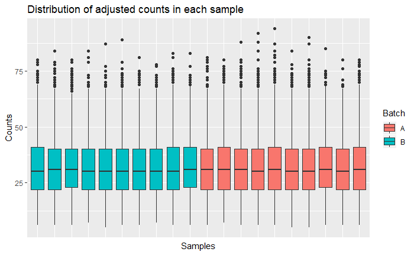

#### Adjusted counts in genes

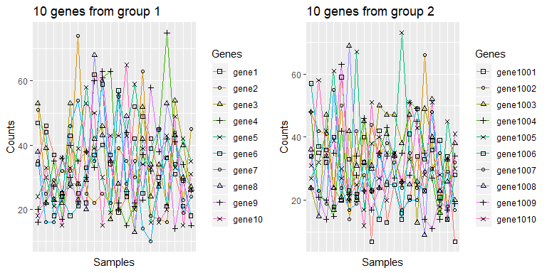

#### Clustering of samples after adjustment

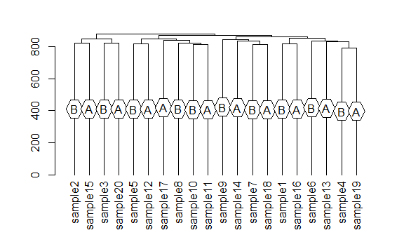

## Thoughts

- This ComBat-seq algorithm doesn’t deal with library size (sequencing depth) differences that are caused by batch.
- Magnitude of batch effect (GLM takes log)
- The benefit of ComBat-seq algorithm? How does it compare with simply adding batch in edgeR linear model?